# Big Data na Prática 4 - Customer Churn Analytics

```
## 'data.frame':    7043 obs. of  21 variables:
##  $ customerID      : Factor w/ 7043 levels "0002-ORFBO","0003-MKNFE",..: 5376 3963 2565 5536 6512 6552 1003 4771 5605 4535 ...
##  $ gender          : Factor w/ 2 levels "Female","Male": 1 2 2 2 1 1 2 1 1 2 ...
##  $ SeniorCitizen   : int  0 0 0 0 0 0 0 0 0 0 ...
##  $ Partner         : Factor w/ 2 levels "No","Yes": 2 1 1 1 1 1 1 1 2 1 ...
##  $ Dependents      : Factor w/ 2 levels "No","Yes": 1 1 1 1 1 1 2 1 1 2 ...
##  $ tenure          : int  1 34 2 45 2 8 22 10 28 62 ...
##  $ PhoneService    : Factor w/ 2 levels "No","Yes": 1 2 2 1 2 2 2 1 2 2 ...
##  $ MultipleLines   : Factor w/ 3 levels "No","No phone service",..: 2 1 1 2 1 3 3 2 3 1 ...
##  $ InternetService : Factor w/ 3 levels "DSL","Fiber optic",..: 1 1 1 1 2 2 2 1 2 1 ...
##  $ OnlineSecurity  : Factor w/ 3 levels "No","No internet service",..: 1 3 3 3 1 1 1 3 1 3 ...
##  $ OnlineBackup    : Factor w/ 3 levels "No","No internet service",..: 3 1 3 1 1 1 3 1 1 3 ...
##  $ DeviceProtection: Factor w/ 3 levels "No","No internet service",..: 1 3 1 3 1 3 1 1 3 1 ...
##  $ TechSupport     : Factor w/ 3 levels "No","No internet service",..: 1 1 1 3 1 1 1 1 3 1 ...
##  $ StreamingTV     : Factor w/ 3 levels "No","No internet service",..: 1 1 1 1 1 3 3 1 3 1 ...
##  $ StreamingMovies : Factor w/ 3 levels "No","No internet service",..: 1 1 1 1 1 3 1 1 3 1 ...
##  $ Contract        : Factor w/ 3 levels "Month-to-month",..: 1 2 1 2 1 1 1 1 1 2 ...
##  $ PaperlessBilling: Factor w/ 2 levels "No","Yes": 2 1 2 1 2 2 2 1 2 1 ...
##  $ PaymentMethod   : Factor w/ 4 levels "Bank transfer (automatic)",..: 3 4 4 1 3 3 2 4 3 1 ...
##  $ MonthlyCharges  : num  29.9 57 53.9 42.3 70.7 ...
##  $ TotalCharges    : num  29.9 1889.5 108.2 1840.8 151.7 ...
##  $ Churn           : Factor w/ 2 levels "No","Yes": 1 1 2 1 2 2 1 1 2 1 ...
```

Os dados brutos contém 7043 linhas (clientes) e 21 colunas (recursos). A coluna “Churn” é o nosso alvo.

```
##       customerID           gender    SeniorCitizen          Partner
##                0                0                0                0
##       Dependents           tenure     PhoneService    MultipleLines
##                0                0                0                0
##  InternetService   OnlineSecurity     OnlineBackup DeviceProtection
##                0                0                0                0
##      TechSupport      StreamingTV  StreamingMovies         Contract
##                0                0                0                0
## PaperlessBilling    PaymentMethod   MonthlyCharges     TotalCharges
##                0                0                0               11
##            Churn
##                0
```

1. Vamos mudar “No internet service” para “No” por seis colunas, que são: “OnlineSecurity”, “OnlineBackup”, “DeviceProtection”, “TechSupport”, “streamingTV”, “streamingMovies”.
2. Vamos mudar “No phone service” para “No” para a coluna “MultipleLines”

Como a permanência mínima é de 1 mês e a permanência máxima é de 72 meses, podemos agrupá-los em cinco grupos de posse (tenure): “0-12 Mês”, “12–24 Mês”, “24–48 Meses”, “48–60 Mês” Mês ”,“> 60 Mês”

```
## [1] 1
```

```
## [1] 72
```

Alteramos os valores na coluna “SeniorCitizen” de 0 ou 1 para “No” ou “Yes”.

Removemos as colunas que não precisamos para a análise.

##Análise exploratória de dados e seleção de recursos

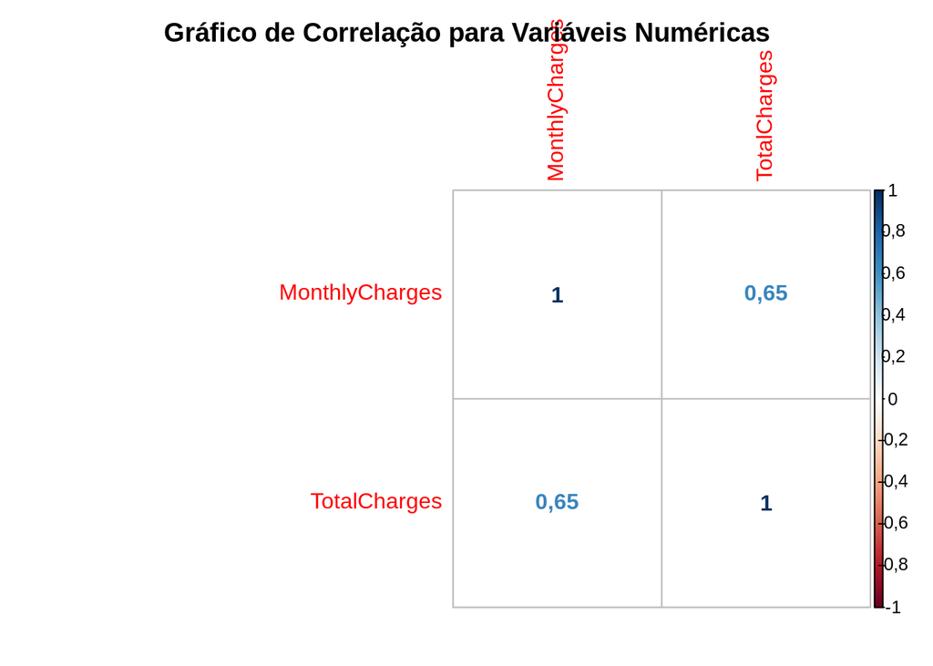

Os encargos mensais e os encargos totais estão correlacionados.

## Gráficos de barra de variáveis categóricas

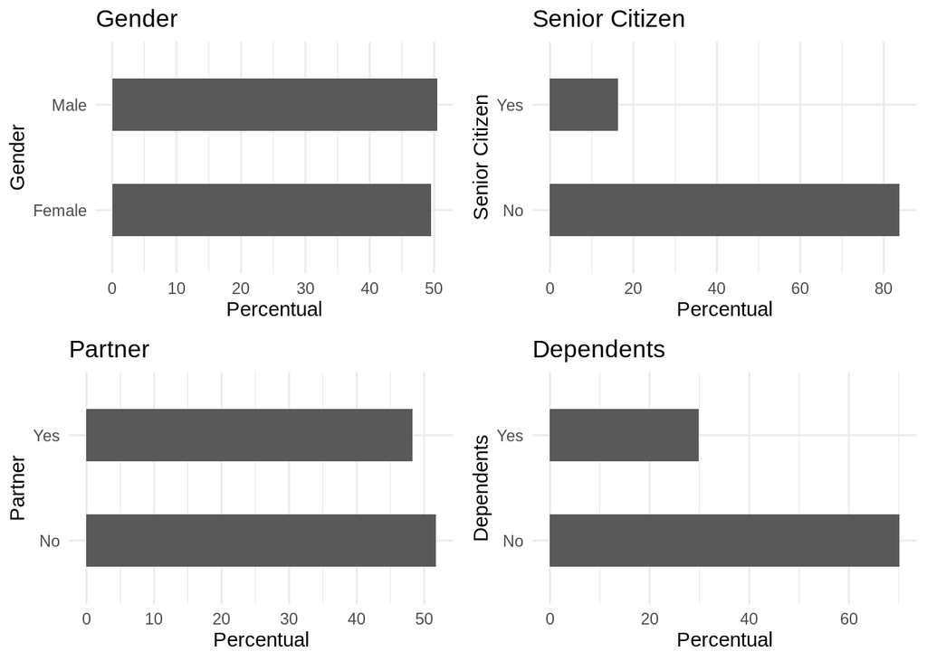

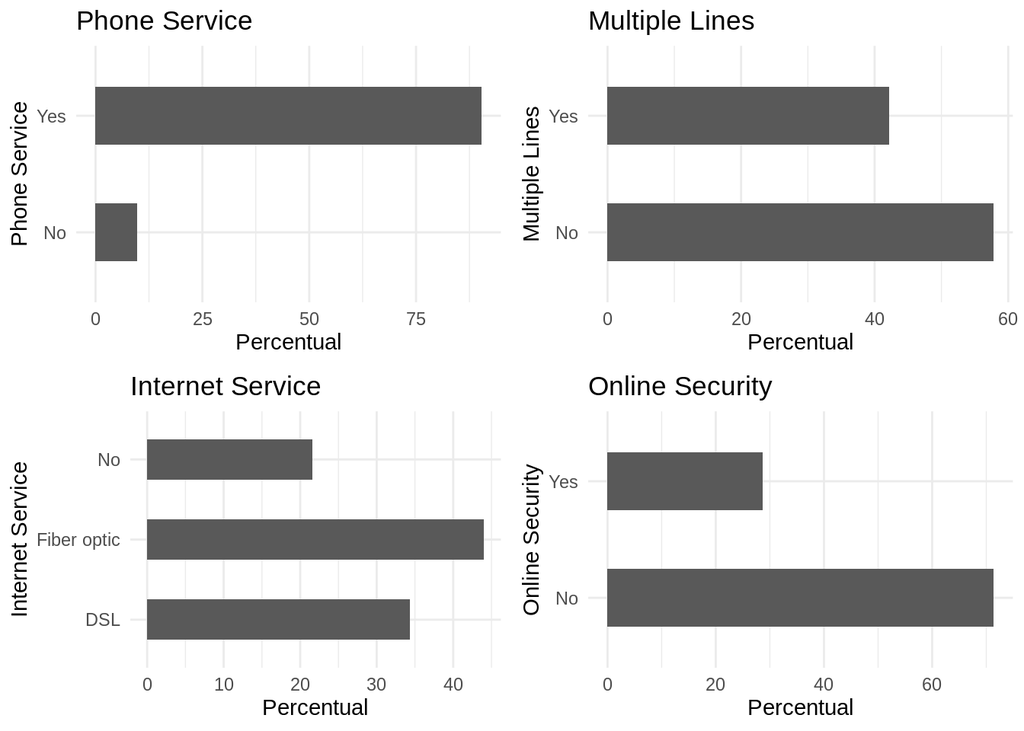

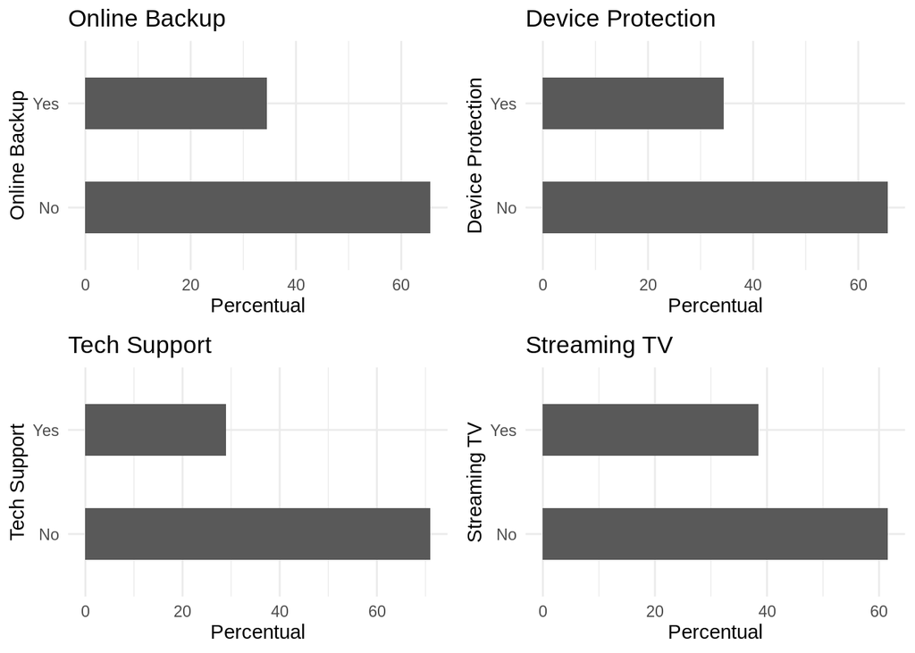

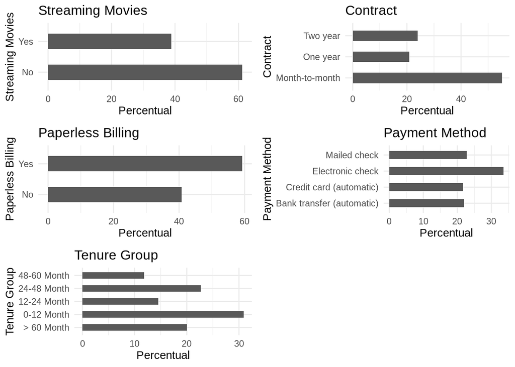

Todas as variáveis categóricas parecem ter uma distribuição razoavelmente ampla, portanto, todas elas serão mantidas para análise posterior.

## Regressão Logística

Primeiro, dividimos os dados em conjuntos de treinamento e testes

Confirme se a divisão está correta

```
## [1] 4924   19
```

```
## [1] 2108   19
```

Treinando o modelo de regressão logística

```
##
## Call:
## glm(formula = Churn ~ ., family = binomial(link = "logit"), data = training)
##
## Deviance Residuals:
##     Min       1Q   Median       3Q      Max
## -1,9483  -0,6731  -0,2883   0,6939   3,0578
##
## Coefficients:
##                                      Estimate Std. Error z value Pr(>|z|)
## (Intercept)                          -0,89099    0,98491  -0,905 0,365660
## genderMale                           -0,02089    0,07750  -0,270 0,787529
## SeniorCitizenYes                      0,19928    0,10093   1,974 0,048339 *
## PartnerYes                           -0,05044    0,09266  -0,544 0,586197
## DependentsYes                        -0,18041    0,10759  -1,677 0,093574 .
## PhoneServiceYes                       0,20648    0,78093   0,264 0,791472
## MultipleLinesYes                      0,38230    0,21127   1,809 0,070374 .
## InternetServiceFiber optic            1,78752    0,95774   1,866 0,061986 .
## InternetServiceNo                    -1,71683    0,96844  -1,773 0,076265 .
## OnlineSecurityYes                    -0,23969    0,21501  -1,115 0,264954
## OnlineBackupYes                       0,03801    0,21142   0,180 0,857309
## DeviceProtectionYes                   0,16767    0,21171   0,792 0,428369
## TechSupportYes                       -0,28266    0,21614  -1,308 0,190944
## StreamingTVYes                        0,57410    0,39071   1,469 0,141728
## StreamingMoviesYes                    0,56484    0,39266   1,439 0,150291
## ContractOne year                     -0,82319    0,12810  -6,426 1,31e-10 ***
## ContractTwo year                     -1,62646    0,21200  -7,672 1,69e-14 ***
## PaperlessBillingYes                   0,25304    0,08830   2,866 0,004160 **
## PaymentMethodCredit card (automatic) -0,04369    0,13747  -0,318 0,750648
## PaymentMethodElectronic check         0,36939    0,11314   3,265 0,001094 **
## PaymentMethodMailed check             0,07257    0,13664   0,531 0,595362
## MonthlyCharges                       -0,03483    0,03809  -0,914 0,360521
## tenure_group0-12 Month                1,61363    0,20377   7,919 2,40e-15 ***
## tenure_group12-24 Month               0,74396    0,20103   3,701 0,000215 ***
## tenure_group24-48 Month               0,40783    0,18429   2,213 0,026903 *
## tenure_group48-60 Month               0,38547    0,19610   1,966 0,049342 *
## ---
## Signif. codes:  0 '***' 0,001 '**' 0,01 '*' 0,05 '.' 0,1 ' ' 1
##
## (Dispersion parameter for binomial family taken to be 1)
##
##     Null deviance: 5702,8  on 4923  degrees of freedom
## Residual deviance: 4106,5  on 4898  degrees of freedom
## AIC: 4158,5
##
## Number of Fisher Scoring iterations: 6
```

Análise de recursos:

1. Os três principais recursos mais relevantes incluem Contrato, Faturamento sem papel e grupo de posse, todos variáveis categóricas.

```
## Analysis of Deviance Table
##
## Model: binomial, link: logit
##
## Response: Churn
##
## Terms added sequentially (first to last)
##
##
##                  Df Deviance Resid. Df Resid. Dev  Pr(>Chi)
## NULL                              4923     5702,8
## gender            1     0,21      4922     5702,5  0,644765
## SeniorCitizen     1    98,20      4921     5604,3 < 2,2e-16 ***
## Partner           1   127,14      4920     5477,2 < 2,2e-16 ***
## Dependents        1    34,70      4919     5442,5 3,848e-09 ***
## PhoneService      1     0,29      4918     5442,2  0,592460
## MultipleLines     1     2,02      4917     5440,2  0,155176
## InternetService   2   485,24      4915     4955,0 < 2,2e-16 ***
## OnlineSecurity    1   173,80      4914     4781,2 < 2,2e-16 ***
## OnlineBackup      1    65,70      4913     4715,5 5,259e-16 ***
## DeviceProtection  1    41,43      4912     4674,0 1,224e-10 ***
## TechSupport       1    98,31      4911     4575,7 < 2,2e-16 ***
## StreamingTV       1     0,75      4910     4575,0  0,384993
## StreamingMovies   1     0,01      4909     4575,0  0,903875
## Contract          2   286,99      4907     4288,0 < 2,2e-16 ***
## PaperlessBilling  1     9,06      4906     4278,9  0,002608 **
## PaymentMethod     3    35,53      4903     4243,4 9,406e-08 ***
## MonthlyCharges    1     0,95      4902     4242,4  0,330881
## tenure_group      4   135,98      4898     4106,5 < 2,2e-16 ***
## ---
## Signif. codes:  0 '***' 0,001 '**' 0,01 '*' 0,05 '.' 0,1 ' ' 1
```

Analisando a tabela de variância, podemos ver a queda no desvio ao adicionar cada variável uma de cada vez. Adicionar InternetService, Contract e tenure_group reduz significativamente o desvio residual. As outras variáveis, como PaymentMethod e Dependents, parecem melhorar menos o modelo, embora todos tenham valores p baixos.

## Avaliando a capacidade preditiva do modelo

```
## [1] "Logistic Regression Accuracy 0,806451612903226"
```

## Confusion Matrix

```
## [1] "Confusion Matrix Para Logistic Regression"
```

```
##
##     FALSE TRUE
##   0  1420  128
##   1   280  280
```

## Odds Ratio

Uma das medidas de desempenho interessantes na regressão logística é Odds Ratio. Basicamente, odds ratio é a chance de um evento acontecer.

```
##                                             OR      2,5 %     97,5 %
## (Intercept)                          0,4102514 0,05942209  2,8260017
## genderMale                           0,9793275 0,84128843  1,1400272
## SeniorCitizenYes                     1,2205200 1,00122234  1,4873135
## PartnerYes                           0,9508113 0,79294603  1,1403216
## DependentsYes                        0,8349241 0,67563675  1,0302583
## PhoneServiceYes                      1,2293412 0,26606058  5,6864068
## MultipleLinesYes                     1,4656514 0,96894171  2,2186165
## InternetServiceFiber optic           5,9746161 0,91606566 39,1617667
## InternetServiceNo                    0,1796350 0,02687392  1,1980959
## OnlineSecurityYes                    0,7868722 0,51600304  1,1989599
## OnlineBackupYes                      1,0387445 0,68639564  1,5725223
## DeviceProtectionYes                  1,1825447 0,78102621  1,7913745
## TechSupportYes                       0,7537749 0,49315751  1,1509366
## StreamingTVYes                       1,7755267 0,82608644  3,8226191
## StreamingMoviesYes                   1,7591616 0,81530490  3,8016772
## ContractOne year                     0,4390296 0,34050821  0,5628092
## ContractTwo year                     0,1966240 0,12805764  0,2944954
## PaperlessBillingYes                  1,2879346 1,08346863  1,5317092
## PaymentMethodCredit card (automatic) 0,9572547 0,73083988  1,2530743
## PaymentMethodElectronic check        1,4468558 1,16009576  1,8079252
## PaymentMethodMailed check            1,0752666 0,82302724  1,4064523
## MonthlyCharges                       0,9657736 0,89622839  1,0405856
## tenure_group0-12 Month               5,0210149 3,37990183  7,5172306
## tenure_group12-24 Month              2,1042456 1,42293419  3,1311568
## tenure_group24-48 Month              1,5035440 1,05098280  2,1660606
## tenure_group48-60 Month              1,4702996 1,00206066  2,1634015
```

## Decision Tree

Para fins de ilustração, vamos usar apenas três variáveis para plotar árvores de decisão, elas são “Contrato”, “tenure_group” e “PaperlessBilling”.

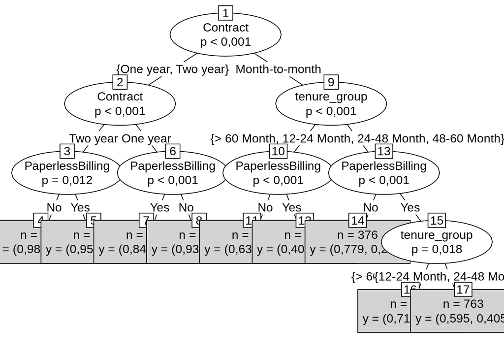

1. Das três variáveis que usamos, o Contrato é a variável mais importante para prever a rotatividade de clientes ou não.
2. Se um cliente em um contrato de um ano ou de dois anos, não importa se ele (ela) tem ou não a PapelessBilling, ele (ela) é menos propenso a se cancelar a assinatura.
3. Por outro lado, se um cliente estiver em um contrato mensal, e no grupo de posse de 0 a 12 meses, e usando o PaperlessBilling, esse cliente terá mais chances de cancelar a assinatura.

```
## [1] "Confusion Matrix for Decision Tree"
```

```
##          Actual
## Predicted   No  Yes
##       No  1398  342
##       Yes  150  218
```

```
## [1] "Decision Tree Accuracy 0,766603415559772"
```

## Random Forest

```
##
## Call:
##  randomForest(formula = Churn ~ ., data = training)
##                Type of random forest: classification
##                      Number of trees: 500
## No. of variables tried at each split: 4
##
##         OOB estimate of  error rate: 21,24%
## Confusion matrix:
##       No Yes class.error
## No  3255 360  0,09958506
## Yes  686 623  0,52406417
```

A previsão é muito boa ao prever “Não”. A taxa de erros é muito maior quando se prevê “sim”.

## Prediction e confusion matrix

```
## Confusion Matrix and Statistics
##
##           Reference
## Prediction   No  Yes
##        No  1398  294
##        Yes  150  266
##
##                Accuracy : 0,7894
##                  95% CI : (0,7713, 0,8066)
##     No Information Rate : 0,7343
##     P-Value [Acc > NIR] : 2,734e-09
##
##                   Kappa : 0,4119
##
##  Mcnemar's Test P-Value : 1,149e-11
##
##             Sensitivity : 0,9031
##             Specificity : 0,4750
##          Pos Pred Value : 0,8262
##          Neg Pred Value : 0,6394
##              Prevalence : 0,7343
##          Detection Rate : 0,6632
##    Detection Prevalence : 0,8027
##       Balanced Accuracy : 0,6891
##
##        'Positive' Class : No
##
```

## Taxa de erro para o modelo de floresta aleatório

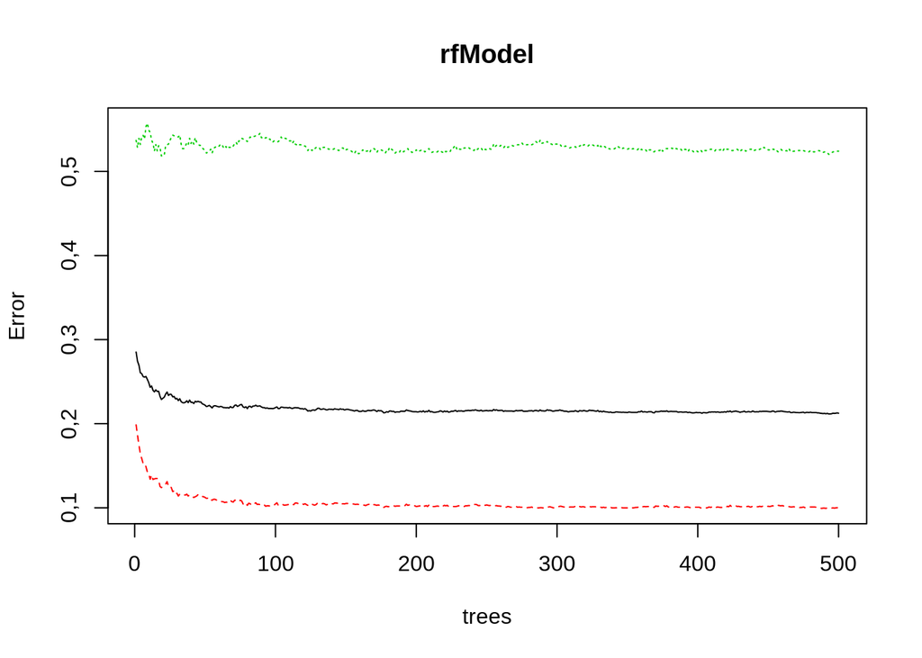

[output not shown]

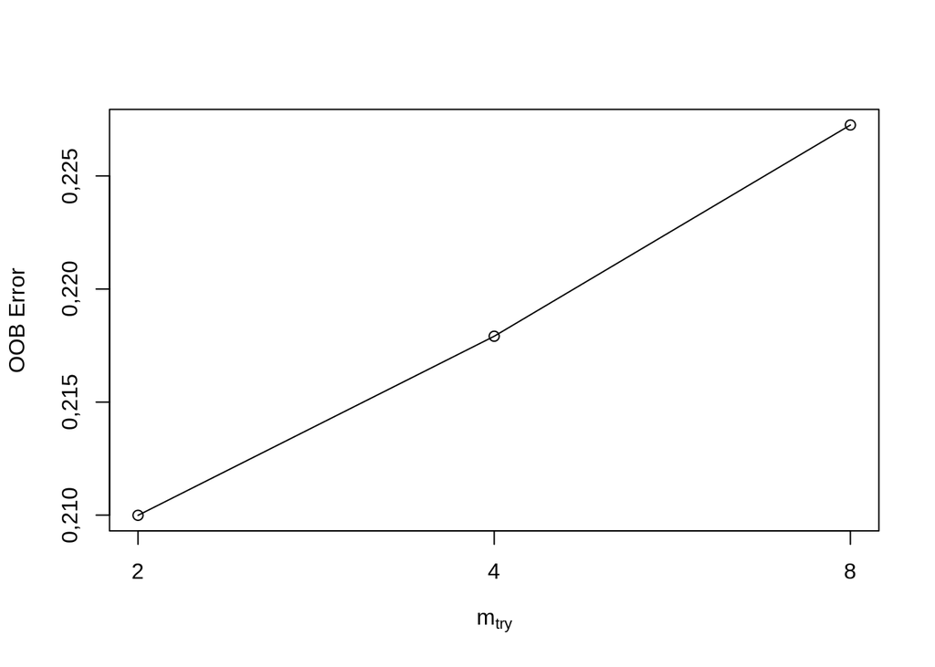

## Ajustar o modelo de floresta aleatório novamente

```
##
## Call:
##  randomForest(formula = Churn ~ ., data = training, ntree = 200,      mtry = 2, importance = TRUE, proximity = TRUE)
##                Type of random forest: classification
##                      Number of trees: 200
## No. of variables tried at each split: 2
##
##         OOB estimate of  error rate: 20,71%
## Confusion matrix:
##       No Yes class.error
## No  3311 304  0,08409405
## Yes  716 593  0,54698243
```

## Torne as previsões e a matriz de confusão novamente

```
## Confusion Matrix and Statistics
##
##           Reference
## Prediction   No  Yes
##        No  1426  302
##        Yes  122  258
##
##                Accuracy : 0,7989
##                  95% CI : (0,7811, 0,8158)
##     No Information Rate : 0,7343
##     P-Value [Acc > NIR] : 3,082e-12
##
##                   Kappa : 0,4256
##
##  Mcnemar's Test P-Value : < 2,2e-16
##
##             Sensitivity : 0,9212
##             Specificity : 0,4607
##          Pos Pred Value : 0,8252
##          Neg Pred Value : 0,6789
##              Prevalence : 0,7343
##          Detection Rate : 0,6765
##    Detection Prevalence : 0,8197
##       Balanced Accuracy : 0,6910
##
##        'Positive' Class : No
##
```

## Random Forest Feature Importance

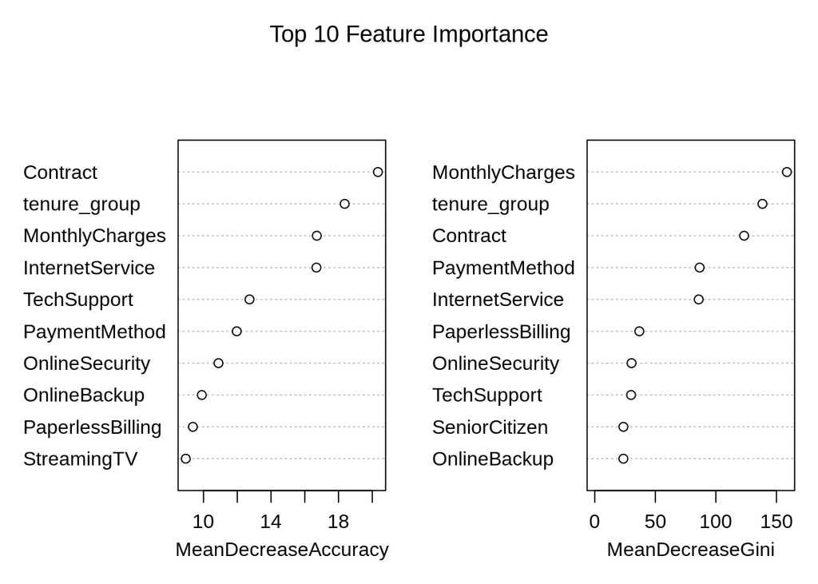